# Assignment 7: Visualization - Some aspects of ggplot2

```r
#Ranking the countries by the highest number of billionaires.

df$country %>% table %>%
  sort(decreasing = TRUE) %>%
  names
```

```
##  [1] "United States"            "China"
##  [3] "India"                    "Germany"
##  [5] "United Kingdom"           "Russia"
##  [7] "Switzerland"              "Hong Kong"
##  [9] "Italy"                    "Singapore"
## [11] "Brazil"                   "Australia"
## [13] "Taiwan"                   "Canada"
## [15] "Japan"                    "France"
## [17] "South Korea"              "Thailand"
## [19] "Israel"                   "Sweden"
## [21] "Indonesia"                "Spain"
## [23] "Turkey"                   "Monaco"
## [25] "United Arab Emirates"     "Philippines"
## [27] "Mexico"                   "Austria"
## [29] "Malaysia"                 "Netherlands"
```

[output cut: 24 more lines]

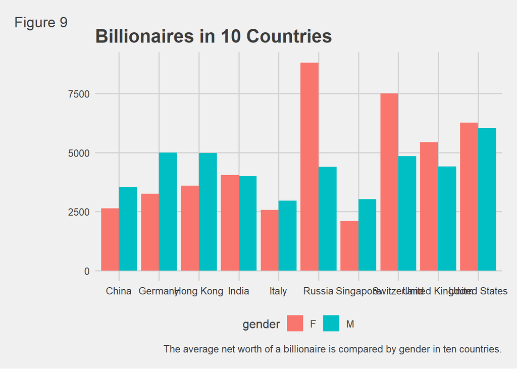

```r
#Making a plot to save.

plot <- df %>% filter(country == "United States"|
                country == "China"| country == "India"|
                country == "Germany"|
                country == "United Kingdom"|
                country =="Russia"|country == "Switzerland"|
                country == "Hong Kong"| country == "Italy"|
                country == "Singapore") %>%
  group_by(country,gender) %>%
  summarise(mean_finalWorth = mean(finalWorth, na.rm = TRUE)) %>%
  ggplot()+
  geom_col(aes(x = country, y = mean_finalWorth, fill = gender), position = 'dodge')+
  labs(title = "Billionaires in 10 Countries",
       caption = "The average net worth of a billionaire is compared by gender in ten countries.",
      tag = "Figure 9",x = "Country",y = " Average Final Worth")+
    theme_fivethirtyeight()
plot
```

```r
#Saving the plot.

ggsave(filename = 'billionaires.png', plot = plot)
```

10. In this question, we will use the Covid19 vaccination data for the US. The data and data dictionary can be found at the below link:
- [Data](https://raw.githubusercontent.com/owid/covid-19-data/master/public/data/vaccinations/vaccinations-by-manufacturer.csv)
- [Alternative Link](https://bryantstats.github.io/math421/data/vaccinations-by-manufacturer.csv)

```r
library(tidyverse)
df <- read_csv('https://raw.githubusercontent.com/owid/covid-19-data/master/public/data/vaccinations/vaccinations-by-manufacturer.csv')
```

`Geom_point` makes scatter plots, which plot two numeric (or Date) variables. A third categorical variable is often brought in for color. For example, we can compare different vaccine types used in the US by

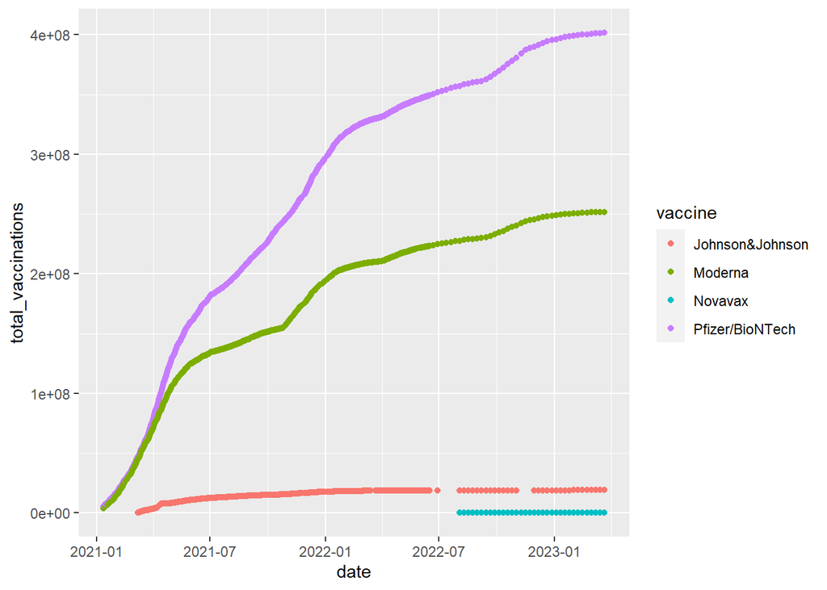

```r
df %>%
  filter(location=='United States') %>%
  ggplot()+
  geom_point(mapping = aes(x = date,
                                    y = total_vaccinations,
                                    color = vaccine))
```

Do the follows.

- Use `geom_point` to compare the vaccines used by date in Argentina in 2022.
- Change `geom_point` to `geom_line` in the above codes to have the corresponding line plots.

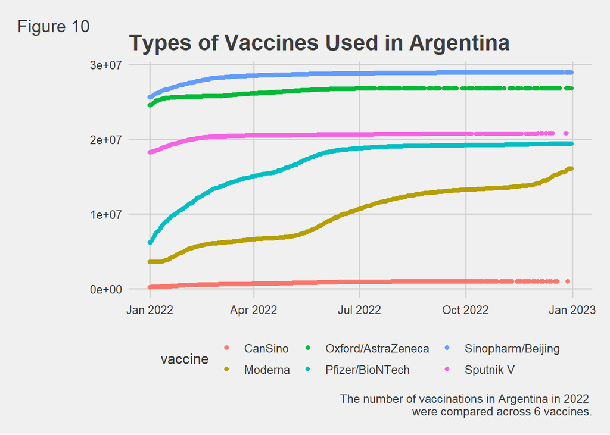

```r
#Filtering by location and year then plotting the total vaccinations by date. The two following graphs compare 6 different types of vaccines used in Argentina in 2022. The most popular vaccine was 'Sinopharm/Beijing while Moderna and Pfizer/BioNTech increased the most in total vaccinations over that year.

df %>%
  filter(location=='Argentina', year(date) == '2022') %>%
  ggplot()+
  geom_point(mapping = aes(x = date,
                                    y = total_vaccinations,
                                    color = vaccine))+
  labs(title = "Types of Vaccines Used in Argentina",
       caption = "The number of vaccinations in Argentina in 2022
       were compared across 6 vaccines.",
      tag = "Figure 10",x = "Date",y = "Total Vaccinations")+
    theme_fivethirtyeight()
```

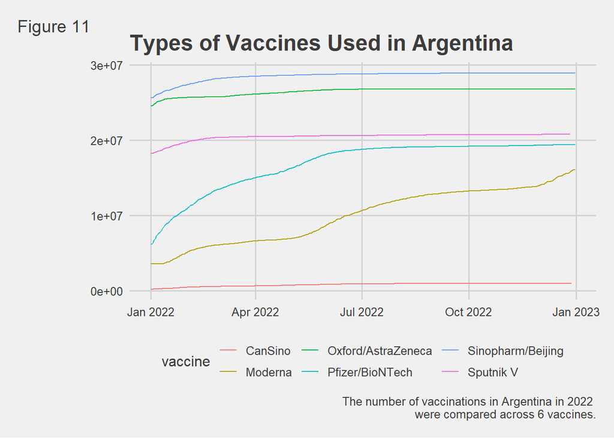

```r
#Filtering by location and year then plotting the total vaccinations by date. This graph is similar to the previous one, but there's a line connecting the observations.

df %>%
  filter(location=='Argentina', year(date) == '2022') %>%
  ggplot()+
  geom_line(mapping = aes(x = date,
                                    y = total_vaccinations,
                                    color = vaccine))+
  labs(title = "Types of Vaccines Used in Argentina",
       caption = "The number of vaccinations in Argentina in 2022
       were compared across 6 vaccines.",
      tag = "Figure 11",x = "Date",y = "Total Vaccinations")+
    theme_fivethirtyeight()
```

11. (Using the same dataset as in 10.) Sometime we need to do some calculations on the data before plotting. For example, the below codes is to compare the total vaccines (including all types of vaccines) by date between the US and the EU

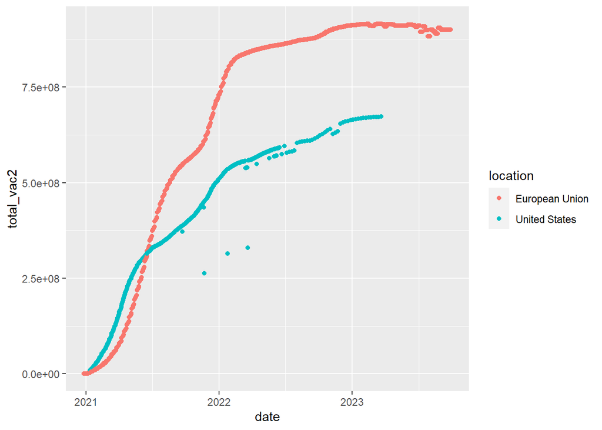

```r
# the total vaccines (including all types of vaccines) by date
d1 <- df %>%
  filter(location %in% c('United States', 'European Union')) %>%
  group_by(date, location) %>%
  summarise(total_vac2=sum(total_vaccinations, na.rm=TRUE))

# Plot
d1 %>%
  ggplot()+
  geom_point(mapping=aes(x=date,
                         y=total_vac2,
                         color=location))
```

Notice that the above codes could be piped in one

```r
df %>%
  filter(location %in% c('United States', 'European Union')) %>%
  group_by(date, location) %>%
  summarise(total_vac2=sum(total_vaccinations, na.rm=TRUE)) %>%
  ggplot()+
  geom_point(mapping=aes(x=date,
                         y=total_vac2,
                         color=location))
```

[output not shown]

Do the follows.